# Assignment 1

## Part 1

#### 1. Consider the following sales data: [2, 15, 20, 5, 1, 4, 7, 9, 10, 3, 14, 8]. Apply the following binning techniques on the data:

##### A. Equal-frequency binning

```python
 data1 = [2, 15, 20, 5, 1, 4, 7, 9, 10, 3, 14, 8]
```

```python
maxdata1 = max(data1);
mindata1 = min(data1);
print (maxdata1);
print (mindata1);
```

```
20
1
```

```python
import pandas as pd
import math
import numpy as np

df = pd.DataFrame()

df['Values']  = data1

nInstances = df.shape[0]

print (nInstances)

df
```

```
12
```

|  | Values |
| --- | --- |
| 0 | 2 |
| 1 | 15 |
| 2 | 20 |
| 3 | 5 |
| 4 | 1 |
| 5 | 4 |
| 6 | 7 |
| 7 | 9 |
| 8 | 10 |
| 9 | 3 |
| 10 | 14 |
| 11 | 8 |

```python
numberBins = math.ceil(math.sqrt(nInstances))
print (numberBins)
```

```
4
```

```python
df3 = df

df3['Bin qcut'] = pd.qcut(df3['Values'], numberBins)

df3
```

|  | Values | Bin qcut |
| --- | --- | --- |
| 0 | 2 | (0.999, 3.75] |
| 1 | 15 | (11.0, 20.0] |
| 2 | 20 | (11.0, 20.0] |
| 3 | 5 | (3.75, 7.5] |
| 4 | 1 | (0.999, 3.75] |
| 5 | 4 | (3.75, 7.5] |
| 6 | 7 | (3.75, 7.5] |
| 7 | 9 | (7.5, 11.0] |
| 8 | 10 | (7.5, 11.0] |
| 9 | 3 | (0.999, 3.75] |
| 10 | 14 | (11.0, 20.0] |
| 11 | 8 | (7.5, 11.0] |

```python
bin_labels2 = ['1', '2', '3', '4']
df3['Bin qcut Label'] = pd.qcut(df3['Values'],numberBins, labels = bin_labels2)
df3
```

|  | Values | Bin qcut | Bin qcut Label |
| --- | --- | --- | --- |
| 0 | 2 | (0.999, 3.75] | 1 |
| 1 | 15 | (11.0, 20.0] | 4 |
| 2 | 20 | (11.0, 20.0] | 4 |
| 3 | 5 | (3.75, 7.5] | 2 |
| 4 | 1 | (0.999, 3.75] | 1 |
| 5 | 4 | (3.75, 7.5] | 2 |
| 6 | 7 | (3.75, 7.5] | 2 |
| 7 | 9 | (7.5, 11.0] | 3 |
| 8 | 10 | (7.5, 11.0] | 3 |
| 9 | 3 | (0.999, 3.75] | 1 |
| 10 | 14 | (11.0, 20.0] | 4 |
| 11 | 8 | (7.5, 11.0] | 3 |

```python
df3
```

|  | Values | Bin qcut | Bin qcut Label |
| --- | --- | --- | --- |
| 0 | 2 | (0.999, 3.75] | 1 |
| 1 | 15 | (11.0, 20.0] | 4 |
| 2 | 20 | (11.0, 20.0] | 4 |
| 3 | 5 | (3.75, 7.5] | 2 |
| 4 | 1 | (0.999, 3.75] | 1 |
| 5 | 4 | (3.75, 7.5] | 2 |
| 6 | 7 | (3.75, 7.5] | 2 |
| 7 | 9 | (7.5, 11.0] | 3 |
| 8 | 10 | (7.5, 11.0] | 3 |
| 9 | 3 | (0.999, 3.75] | 1 |
| 10 | 14 | (11.0, 20.0] | 4 |
| 11 | 8 | (7.5, 11.0] | 3 |

```python
df3.sort_values("Values", axis = 0, ascending = True,
                 inplace = True, na_position ='first')

df3
```

|  | Values | Bin qcut | Bin qcut Label |
| --- | --- | --- | --- |
| 4 | 1 | (0.999, 3.75] | 1 |
| 0 | 2 | (0.999, 3.75] | 1 |
| 9 | 3 | (0.999, 3.75] | 1 |
| 5 | 4 | (3.75, 7.5] | 2 |
| 3 | 5 | (3.75, 7.5] | 2 |
| 6 | 7 | (3.75, 7.5] | 2 |
| 11 | 8 | (7.5, 11.0] | 3 |
| 7 | 9 | (7.5, 11.0] | 3 |
| 8 | 10 | (7.5, 11.0] | 3 |
| 10 | 14 | (11.0, 20.0] | 4 |
| 1 | 15 | (11.0, 20.0] | 4 |
| 2 | 20 | (11.0, 20.0] | 4 |

##### B. Smoothing by bin means

```python
mean1 = (df3.loc[df3['Bin qcut Label'] == '1']['Values']).mean()
mean2 = (df3.loc[df3['Bin qcut Label'] == '2']['Values']).mean()
mean3 = (df3.loc[df3['Bin qcut Label'] == '3']['Values']).mean()
mean4 = (df3.loc[df3['Bin qcut Label'] == '4']['Values']).mean()
```

```python
print(mean1)
print(mean2)
print(mean3)
print(mean4)
```

```
2.0
5.333333333333333
9.0
16.333333333333332
```

```python
index1 = df3.loc[df3['Bin qcut Label'] == '1'].index
index2 = df3.loc[df3['Bin qcut Label'] == '2'].index
index3 = df3.loc[df3['Bin qcut Label'] == '3'].index
index4 = df3.loc[df3['Bin qcut Label'] == '4'].index
```

```python
print(index1)
print(index2)
print(index3)
print(index4)
```

```
Int64Index([4, 0, 9], dtype='int64')
Int64Index([5, 3, 6], dtype='int64')
Int64Index([11, 7, 8], dtype='int64')
Int64Index([10, 1, 2], dtype='int64')
```

```python
df3.loc[index1,'Values'] = mean1
df3.loc[index2,'Values'] = mean2
df3.loc[index3,'Values'] = mean3
df3.loc[index4,'Values'] = mean4
```

```python
df3
```

[output not shown]

##### C. Smoothing by bin boundaries

```python
dataSlice1 = df3.loc[df3['Bin qcut Label'] == '1', ['Values']]
dataSlice2 = df3.loc[df3['Bin qcut Label'] == '2', ['Values']]
dataSlice3 = df3.loc[df3['Bin qcut Label'] == '3', ['Values']]
dataSlice4 = df3.loc[df3['Bin qcut Label'] == '4', ['Values']]
```

```python
for i in  ( index1.tolist()):
    if dataSlice1.loc[i, "Values"] < mean1:
        df3.loc[i,'Values'] = dataSlice1['Values'].min()
    else:
        df3.loc[i,'Values'] = dataSlice1['Values'].max()

for i in  ( index2.tolist()):
    if dataSlice2.loc[i, "Values"] < mean2:
        df3.loc[i,'Values'] = dataSlice2['Values'].min()
    else:
        df3.loc[i,'Values'] = dataSlice2['Values'].max()

for i in  ( index3.tolist()):
    if dataSlice3.loc[i, "Values"] < mean3:
        df3.loc[i,'Values'] = dataSlice3['Values'].min()
    else:
        df3.loc[i,'Values'] = dataSlice3['Values'].max()

for i in  ( index4.tolist()):
    if dataSlice4.loc[i, "Values"] < mean4:
        df3.loc[i,'Values'] = dataSlice4['Values'].min()
    else:
        df3.loc[i,'Values'] = dataSlice4['Values'].max()
```

```python
df3
```

[output not shown]

#### 2. Use the below methods to normalize the following data: [10, 20, 35, 70, 100]:

##### A. min-max normalization with min=0 and max=1.

```python
import pandas as pd
import math
import numpy as np

data2 = [10, 20, 35, 70, 100]

df = pd.DataFrame()

df['Values']  = data2

nInstances = df.shape[0]

print (nInstances)

df
```

```
5
```

|  | Values |
| --- | --- |
| 0 | 10 |
| 1 | 20 |
| 2 | 35 |
| 3 | 70 |
| 4 | 100 |

```python
#normalized = (x-min(x))/(max(x)-min(x))
normalized_df= (df-df.min())/(df.max()-df.min())
```

```python
normalized_df
```

|  | Values |
| --- | --- |
| 0 | 0.000000 |
| 1 | 0.111111 |
| 2 | 0.277778 |
| 3 | 0.666667 |
| 4 | 1.000000 |

```python
data2 = [10, 20, 35, 70, 100]

df = pd.DataFrame()

df['Values']  = data2

df
```

|  | Values |
| --- | --- |
| 0 | 10 |
| 1 | 20 |
| 2 | 35 |
| 3 | 70 |
| 4 | 100 |

##### B. z-score normalization

```python
z_score_normalized_df=(df-df.mean())/df.std()
z_score_normalized_df
```

|  | Values |
| --- | --- |
| 0 | -0.990637 |
| 1 | -0.722897 |
| 2 | -0.321288 |
| 3 | 0.615801 |
| 4 | 1.419021 |

##### C. normalization with decimal scaling.

```python
data2 = [10, 20, 35, 70, 100]

df = pd.DataFrame()

df['Values']  = data2

df
```

|  | Values |
| --- | --- |
| 0 | 10 |
| 1 | 20 |
| 2 | 35 |
| 3 | 70 |
| 4 | 100 |

```python
for x in df:
    p = df[x].max()
    q = len(str(abs(int(p))))
    df[x] = df[x]/10**q
df
```

|  | Values |
| --- | --- |
| 0 | 0.010 |
| 1 | 0.020 |
| 2 | 0.035 |
| 3 | 0.070 |
| 4 | 0.100 |

#### 3. Suppose that a hospital has kept records for the age and BMI (Body Mass Index) for 16 randomly selected individuals, with the data presented as below. Calculate the correlation coefficient for the two above attributes. Are these two attributes positively or negatively correlated?

| Age | 23 | 23 | 27 | 27 | 39 | 41 | 47 | 49 | 52 | 54 | 54 | 56 | 57 | 58 | 58 | 60 |
| --- | --- | --- | --- | --- | --- | --- | --- | --- | --- | --- | --- | --- | --- | --- | --- | --- |
| BMI | 16 | 19 | 18 | 21 | 24 | 23 | 26 | 25 | 24 | 26 | 23 | 26 | 27 | 31 | 26 | 27 |

```python
import pandas as pd
import math
import numpy as np

dataAge = [23,23,27,27,39,41,47,49,52,54,54,56,57,58,58,60]
dataBMI = [16,19,18,21,24,23,26,25,24,26,23,26,27,31,26,27]

df = pd.DataFrame({"Age": dataAge,
                   "BMI": dataBMI})
df
```

|  | Age | BMI |
| --- | --- | --- |
| 0 | 23 | 16 |
| 1 | 23 | 19 |
| 2 | 27 | 18 |
| 3 | 27 | 21 |
| 4 | 39 | 24 |
| 5 | 41 | 23 |
| 6 | 47 | 26 |
| 7 | 49 | 25 |
| 8 | 52 | 24 |
| 9 | 54 | 26 |
| 10 | 54 | 23 |
| 11 | 56 | 26 |
| 12 | 57 | 27 |
| 13 | 58 | 31 |
| 14 | 58 | 26 |
| 15 | 60 | 27 |

```python
corrrelation = df.corr(method="pearson");

print("Pearson correlation coefficient:");

print(corrrelation);
```

```
Pearson correlation coefficient:
          Age       BMI
Age  1.000000  0.891108
BMI  0.891108  1.000000
```

```python
import pingouin as pg
pg.corr(x=df['Age'], y=df['BMI'])
```

|  | n | r | CI95% | r2 | adj_r2 | p-val | BF10 | power |
| --- | --- | --- | --- | --- | --- | --- | --- | --- |
| pearson | 16 | 0.891108 | [0.71, 0.96] | 0.794074 | 0.762393 | 0.000004 | 5138.535 | 0.999491 |

these two attributes positively correlated with a correlation coefficient of r = 0.89

#### 4. Patients at two hospitals, Hospital A and Hospital B, have been provided with feedback forms on patient satisfaction, with the below responses recorded. Is patient satisfaction correlated with a specific hospital? Use a chi-square test to find out, assuming a significance level of 0.001 and a corresponding chi-square significance value of 10.828.

| Rating/Hospital | Hospital A | Hospital B |
| --- | --- | --- |
| Satisfied | 71 | 129 |
| Dissatisfied | 37 | 73 |

```python
import pandas as pd
import numpy as np
import pingouin as pg
from scipy.stats import chi2_contingency
```

```python
df = pd.DataFrame({'Hospital A' : [71 , 37],
                   'Hospital B' : [129, 73 ]},
                   index =['Satisfied', 'Dissatisfied']
                  )
df
```

|  | Hospital A | Hospital B |
| --- | --- | --- |
| Satisfied | 71 | 129 |
| Dissatisfied | 37 | 73 |

```python
c, p, dof, expected = chi2_contingency(df,correction=False)
print('chi2 = ' , c)
print('p value = ' , p)
print('dof = ' , dof)
print('expected = \n' , expected)
```

```
chi2 =  0.10857544087742113
p value =  0.7417718412505765
dof =  1
expected =
 [[ 69.67741935 130.32258065]
 [ 38.32258065  71.67741935]]
```

Satisfaction is not correlated with a specific hospital beacause p value is more than 0.001 meaning they are independent

```python
#data = pg.read_dataset('chi2_independence')
#expected, observed, stats = pg.chi2_independence(df, x='Hospital A', y='Hospital B')
#observed
```

#### 5. Load the CSV file BL_books.csv, which includes records of books hosted at the British Library. Inspect the data and describe any issues observed with the data. Remove fields that refer to internal processes at the British Library and do not describe the books themselves (Corporate Author, Corporate Contributors, Issuance type, Former owner, Shelfmarks, Engraver). Clean data in column Date of Publication, as to remove the extra dates in square brackets (e.g. 1879 [1878] -> 1879) and convert date ranges to their start date, wherever present (e.g. 1860-63 -> 1860).

```python
import pandas as pd
import numpy as np
import re

df = pd.read_csv('./BL-books.csv', index_col ="Identifier")
```

```python
df.head()
```

| Identifier | Edition Statement | Place of Publication | Date of Publication | Publisher | Title | Author | Contributors | Corporate Author | Corporate Contributors | Former owner | Engraver | Issuance type | Flickr URL | Shelfmarks |
| --- | --- | --- | --- | --- | --- | --- | --- | --- | --- | --- | --- | --- | --- | --- |
| 206 | NaN | London | 1879 [1878] | S. Tinsley & Co. | Walter Forbes. [A novel.] By A. A | A. A. | FORBES, Walter. | NaN | NaN | NaN | NaN | monographic | http://www.flickr.com/photos/britishlibrary/ta... | British Library HMNTS 12641.b.30. |
| 216 | NaN | London; Virtue & Yorston | 1868 | Virtue & Co. | All for Greed. [A novel. The dedication signed... | A., A. A. | BLAZE DE BURY, Marie Pauline Rose - Baroness | NaN | NaN | NaN | NaN | monographic | http://www.flickr.com/photos/britishlibrary/ta... | British Library HMNTS 12626.cc.2. |
| 218 | NaN | London | 1869 | Bradbury, Evans & Co. | Love the Avenger. By the author of “All for Gr... | A., A. A. | BLAZE DE BURY, Marie Pauline Rose - Baroness | NaN | NaN | NaN | NaN | monographic | http://www.flickr.com/photos/britishlibrary/ta... | British Library HMNTS 12625.dd.1. |
| 472 | NaN | London | 1851 | James Darling | Welsh Sketches, chiefly ecclesiastical, to the... | A., E. S. | Appleyard, Ernest Silvanus. | NaN | NaN | NaN | NaN | monographic | http://www.flickr.com/photos/britishlibrary/ta... | British Library HMNTS 10369.bbb.15. |
| 480 | A new edition, revised, etc. | London | 1857 | Wertheim & Macintosh | [The World in which I live, and my place in it... | A., E. S. | BROOME, John Henry. | NaN | NaN | NaN | NaN | monographic | http://www.flickr.com/photos/britishlibrary/ta... | British Library HMNTS 9007.d.28. |

```python
#(df['Date of Publication'].str.strip().values == "nan" ).sum()

print('Number of instances = %d' % (df.shape[0]))
print('Number of attributes = %d' % (df.shape[1]))

for col in df.columns:
    print('\t%s: %d' % ( col,df[col].isna().sum() ) )
```

```
Number of instances = 8287
Number of attributes = 14
	Edition Statement: 7514
	Place of Publication: 0
	Date of Publication: 181
	Publisher: 4195
	Title: 0
	Author: 1778
	Contributors: 0
	Corporate Author: 8287
	Corporate Contributors: 8287
	Former owner: 8286
	Engraver: 8287
	Issuance type: 0
	Flickr URL: 0
	Shelfmarks: 0
```

```python
df.loc[667,'Date of Publication']
```

```
nan
```

```python
import pandas as pd
import numpy as np
import re

df = pd.read_csv('./BL-books.csv', index_col ="Identifier")

df['Date of Publication'] = df['Date of Publication'].replace(np.NaN,9999)


df['Date of Publication'] = df['Date of Publication'].astype(str)

N=4


def filterNumber(n):

    if(len(n)==4):
        return True
    else:
        return False


for index in df.index:

    temp = []
    tempBracket = []
    res = []
    resBracket = []


    tempBracket = re.findall(r'\[.*?\]', df.loc[index,'Date of Publication'])

    if len(tempBracket) > 0:

        tempBracket = re.findall(r'\d+', tempBracket[0])


    a_string = df.loc[index,'Date of Publication']
    b_string = re.sub(r" ?\[[^)]+\]", "", a_string )
    temp = re.findall(r'\d+', b_string)


#    for word in a_string.split():
#        if word.isdigit():
#              temp.append(word)


    if len(temp) > 0 and temp[0] == '9999':

        temp = re.findall(r'\d+', df.loc[index,'Place of Publication'])


    res = list(filter(filterNumber, temp))
    resBracket = list(filter(filterNumber, tempBracket))


    if len(res) > 0 :

        intrRes = [int(i) for i in res]
        minDate = min(intrRes)
        df.at[index,'Date of Publication'] = str(minDate)
        #print(str(minDate))

    elif len(resBracket) > 0 and len(res) <= 0 :

        intrRes = [int(i) for i in resBracket]
        minDate = min(intrRes)
        df.at[index,'Date of Publication'] = str(minDate)
        #print(str(minDate))
```

```python
print("These books had no date anywhere in their records!")
df.loc[df['Date of Publication'].str.len() != 4 ]['Place of Publication']
```

```
These books had no date anywhere in their records!
```

```
Identifier
516336     London
3605102    Oxford
Name: Place of Publication, dtype: object
```

```python
df.loc[2167220,'Date of Publication']
```

```
'1890'
```

```python
df = df.drop(columns=['Contributors', 'Corporate Author','Corporate Contributors','Former owner','Engraver','Issuance type'])
```

```python
df
```

| Identifier | Edition Statement | Place of Publication | Date of Publication | Publisher | Title | Author | Flickr URL | Shelfmarks |
| --- | --- | --- | --- | --- | --- | --- | --- | --- |
| 206 | NaN | London | 1879 | S. Tinsley & Co. | Walter Forbes. [A novel.] By A. A | A. A. | http://www.flickr.com/photos/britishlibrary/ta... | British Library HMNTS 12641.b.30. |
| 216 | NaN | London; Virtue & Yorston | 1868 | Virtue & Co. | All for Greed. [A novel. The dedication signed... | A., A. A. | http://www.flickr.com/photos/britishlibrary/ta... | British Library HMNTS 12626.cc.2. |
| 218 | NaN | London | 1869 | Bradbury, Evans & Co. | Love the Avenger. By the author of “All for Gr... | A., A. A. | http://www.flickr.com/photos/britishlibrary/ta... | British Library HMNTS 12625.dd.1. |
| 472 | NaN | London | 1851 | James Darling | Welsh Sketches, chiefly ecclesiastical, to the... | A., E. S. | http://www.flickr.com/photos/britishlibrary/ta... | British Library HMNTS 10369.bbb.15. |
| 480 | A new edition, revised, etc. | London | 1857 | Wertheim & Macintosh | [The World in which I live, and my place in it... | A., E. S. | http://www.flickr.com/photos/britishlibrary/ta... | British Library HMNTS 9007.d.28. |
| ... | ... | ... | ... | ... | ... | ... | ... | ... |
| 4158088 | NaN | London | 1838 | NaN | The Parochial History of Cornwall, founded on,... | GIDDY, afterwards GILBERT, Davies. | http://www.flickr.com/photos/britishlibrary/ta... | British Library HMNTS\|British Library HMNTS 10... |
| 4158128 | NaN | Derby | 1831 | M. Mozley & Son | The History and Gazetteer of the County of Der... | GLOVER, Stephen - of Derby | http://www.flickr.com/photos/britishlibrary/ta... | British Library HMNTS\|British Library HMNTS 10... |
| 4159563 | NaN | London | 1806 | T. Cadell and W. Davies | Magna Britannia; being a concise topographical... | LYSONS, Daniel - M.A., F.R.S., and LYSONS (Sam... | http://www.flickr.com/photos/britishlibrary/ta... | British Library HMNTS\|British Library HMNTS 19... |
| 4159587 | NaN | Newcastle upon Tyne | 1834 | Mackenzie & Dent | An historical, topographical and descriptive v... | Mackenzie, E. (Eneas) | http://www.flickr.com/photos/britishlibrary/ta... | British Library HMNTS\|British Library HMNTS 10... |
| 4160339 | NaN | London | 1834 | NaN | Collectanea Topographica et Genealogica. [Firs... | NaN | http://www.flickr.com/photos/britishlibrary/ta... | British Library HMNTS\|British Library HMNTS 79... |

8287 rows × 8 columns

#### 6. Load the CSV file country-income.csv which includes both numerical and categorical values. Perform data cleaning in order to replace any NaN values with the mean of the value for a given field. Then replace any categorical labels with numerical labels. Display the resulting dataset. You can use the sklearn.impute and sklearn.preprocessing packages to asssist you.

```python
import pandas as pd
import numpy as np
import re
from sklearn.preprocessing import LabelEncoder

df = pd.read_csv('./country-income.csv')
```

```python
df
```

|  | Region | Age | Income | Online Shopper |
| --- | --- | --- | --- | --- |
| 0 | India | 49.0 | 86400.0 | No |
| 1 | Brazil | 32.0 | 57600.0 | Yes |
| 2 | USA | 35.0 | 64800.0 | No |
| 3 | Brazil | 43.0 | 73200.0 | No |
| 4 | USA | 45.0 | NaN | Yes |
| 5 | India | 40.0 | 69600.0 | Yes |
| 6 | Brazil | NaN | 62400.0 | No |
| 7 | India | 53.0 | 94800.0 | Yes |
| 8 | USA | 55.0 | 99600.0 | No |
| 9 | India | 42.0 | 80400.0 | Yes |

```python
mean1 = (df.loc[df['Region'] == 'USA','Income']).mean()

print(mean1)

df.at[df['Region'] == 'USA','Income'] = df.loc[df['Region'] == 'USA','Income'].fillna(mean1)

df['Income']
```

```
82200.0
```

```
0    86400.0
1    57600.0
2    64800.0
3    73200.0
4    82200.0
5    69600.0
6    62400.0
7    94800.0
8    99600.0
9    80400.0
Name: Income, dtype: float64
```

```python
mean2 = (df.loc[df['Region'] == 'Brazil','Age'].mean())

print(mean2)

df.at[df['Region'] == 'Brazil','Age'] = df.loc[df['Region'] == 'Brazil','Age'].fillna(mean2)

df['Age']
```

```
37.5
```

```
0    49.0
1    32.0
2    35.0
3    43.0
4    45.0
5    40.0
6    37.5
7    53.0
8    55.0
9    42.0
Name: Age, dtype: float64
```

```python
def Encoder(df):
    columnsToEncode = list(df.select_dtypes(include=['category','object']))
    le = LabelEncoder()
    for feature in columnsToEncode:
        try:
            df[feature] = le.fit_transform(df[feature])
        except:
            print('Error encoding '+feature)
    return df
df = Encoder(df)
```

```python
df
```

|  | Region | Age | Income | Online Shopper |
| --- | --- | --- | --- | --- |
| 0 | 1 | 49.0 | 86400.0 | 0 |
| 1 | 0 | 32.0 | 57600.0 | 1 |
| 2 | 2 | 35.0 | 64800.0 | 0 |
| 3 | 0 | 43.0 | 73200.0 | 0 |
| 4 | 2 | 45.0 | 82200.0 | 1 |
| 5 | 1 | 40.0 | 69600.0 | 1 |
| 6 | 0 | 37.5 | 62400.0 | 0 |
| 7 | 1 | 53.0 | 94800.0 | 1 |
| 8 | 2 | 55.0 | 99600.0 | 0 |
| 9 | 1 | 42.0 | 80400.0 | 1 |

#### 7. Load the CSV file shoesize.csv, which includes measurements of shoe size and height (in inches) for 408 subjects, both female and male. Plot the scatterplots of shoe size versus height for female and male subjects separately. Compute the Pearson's correlation coefficient of shoe size versus height for female and male subjects separately. What can be inferred by the scatterplots and computed correlation coefficients? You can implement your own formulation of the correlation coefficient or use the scipy.stats package to assist you.

```python
import pandas as pd
import numpy as np
import re
import matplotlib.pyplot as plt
import math
import pingouin as pg


from sklearn.preprocessing import LabelEncoder

df = pd.read_csv('./shoesize.csv', index_col ="Index")
```

```python
df.head()
```

| Index | Gender | Size | Height |
| --- | --- | --- | --- |
| 1 | F | 5.5 | 60.0 |
| 2 | F | 6.0 | 60.0 |
| 3 | F | 7.0 | 60.0 |
| 4 | F | 8.0 | 60.0 |
| 5 | F | 8.0 | 60.0 |

```python
df.loc[df['Gender'] == 'F',['Height','Size']]
```

| Index | Height | Size |
| --- | --- | --- |
| 1 | 60.0 | 5.5 |
| 2 | 60.0 | 6.0 |
| 3 | 60.0 | 7.0 |
| 4 | 60.0 | 8.0 |
| 5 | 60.0 | 8.0 |
| ... | ... | ... |
| 183 | 72.0 | 10.0 |
| 184 | 72.0 | 11.0 |
| 185 | 72.0 | 11.0 |
| 186 | 74.0 | 10.0 |
| 187 | 74.0 | 11.0 |

187 rows × 2 columns

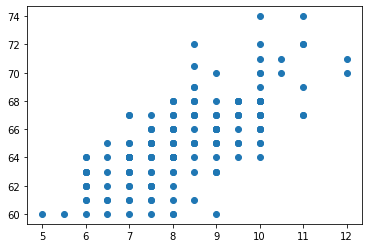

```python
# Here we subset your dataframe where the temperature is 90, which will give you a
# boolean array for your dataframe.
df1 = df.loc[df['Gender'] == 'F',['Height','Size']]
# Apply your boolean against your dataframe to grab the correct rows:


# Now plot your scatter plot
plt.scatter(x=df1['Size'] ,y=df1['Height'])
plt.show()
```

```python
corrrelation = df1.corr(method="pearson");

print("Pearson correlation coefficient:");

print(corrrelation);
```

```
Pearson correlation coefficient:
          Height      Size
Height  1.000000  0.707812
Size    0.707812  1.000000
```

```python
pg.corr(x=df1['Height'], y=df1['Size'])
```

|  | n | r | CI95% | r2 | adj_r2 | p-val | BF10 | power |
| --- | --- | --- | --- | --- | --- | --- | --- | --- |
| pearson | 187 | 0.707812 | [0.63, 0.77] | 0.500998 | 0.495574 | 9.773451e-30 | 3.894e+26 | 1.0 |

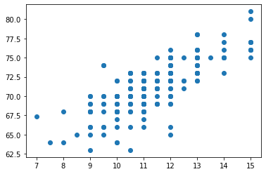

```python
df2 = df.loc[df['Gender'] == 'M',['Height','Size']]
# Apply your boolean against your dataframe to grab the correct rows:


# Now plot your scatter plot
plt.scatter(x=df2['Size'] ,y=df2['Height'])
plt.show()
```

```python
corrrelation = df2.corr(method="pearson");

print("Pearson correlation coefficient:");

print(corrrelation);
```

```
Pearson correlation coefficient:
          Height      Size
Height  1.000000  0.767709
Size    0.767709  1.000000
```

```python
pg.corr(x=df2['Height'], y=df2['Size'])
```

|  | n | r | CI95% | r2 | adj_r2 | p-val | BF10 | power |
| --- | --- | --- | --- | --- | --- | --- | --- | --- |
| pearson | 221 | 0.767709 | [0.71, 0.82] | 0.589378 | 0.58561 | 3.285711e-44 | 7.449e+40 | 1.0 |

From the scatterplot and the correlation coefficient we infer that the height and are relatively correlated fro both genders

#### 8. Using the breast cancer dataset from section 1 of this notebook, perform Principal Component Analysis with 2 components. Compute the explained variance ratio for each component, and plot the scatterplot of all samples along the two principal components, color-coded according to the "Class" column (this column should not be used in the PCA analysis). Ensure that your data is normalized prior to performing PCA. What insights can you obtain by the explained variance ratio of each component, and by viewing the scatterplot of the principal components?

```python
import matplotlib.image as mpimg
import numpy as np
import pandas as pd
from scipy import stats
import re
import matplotlib.pyplot as plt
import math
import pingouin as pg
from sklearn.decomposition import PCA
from sklearn.preprocessing import StandardScaler



data = pd.read_csv('./breast-cancer-wisconsin.csv', header=None)
data.columns = ['Sample code', 'Clump Thickness', 'Uniformity of Cell Size', 'Uniformity of Cell Shape',
                'Marginal Adhesion', 'Single Epithelial Cell Size', 'Bare Nuclei', 'Bland Chromatin',
                'Normal Nucleoli', 'Mitoses','Class']

data = data.drop(['Sample code'],axis=1)
print('Number of instances = %d' % (data.shape[0]))
print('Number of attributes = %d' % (data.shape[1]))
#data.head()

data = data.replace('?',np.NaN)
data = data.fillna(data.median())

data['Bare Nuclei'] = pd.to_numeric(data['Bare Nuclei'])

data[(np.abs(stats.zscore(data)) < 3).all(axis=1)]

data.drop_duplicates()
```

```
Number of instances = 699
Number of attributes = 10
```

|  | Clump Thickness | Uniformity of Cell Size | Uniformity of Cell Shape | Marginal Adhesion | Single Epithelial Cell Size | Bare Nuclei | Bland Chromatin | Normal Nucleoli | Mitoses | Class |
| --- | --- | --- | --- | --- | --- | --- | --- | --- | --- | --- |
| 0 | 5 | 1 | 1 | 1 | 2 | 1.0 | 3 | 1 | 1 | 2 |
| 1 | 5 | 4 | 4 | 5 | 7 | 10.0 | 3 | 2 | 1 | 2 |
| 2 | 3 | 1 | 1 | 1 | 2 | 2.0 | 3 | 1 | 1 | 2 |
| 3 | 6 | 8 | 8 | 1 | 3 | 4.0 | 3 | 7 | 1 | 2 |
| 4 | 4 | 1 | 1 | 3 | 2 | 1.0 | 3 | 1 | 1 | 2 |
| ... | ... | ... | ... | ... | ... | ... | ... | ... | ... | ... |
| 693 | 3 | 1 | 1 | 1 | 2 | 1.0 | 2 | 1 | 2 | 2 |
| 694 | 3 | 1 | 1 | 1 | 3 | 2.0 | 1 | 1 | 1 | 2 |
| 696 | 5 | 10 | 10 | 3 | 7 | 3.0 | 8 | 10 | 2 | 4 |
| 697 | 4 | 8 | 6 | 4 | 3 | 4.0 | 10 | 6 | 1 | 4 |
| 698 | 4 | 8 | 8 | 5 | 4 | 5.0 | 10 | 4 | 1 | 4 |

457 rows × 10 columns

```python
features = list(data.columns)
features.remove('Class')
features
```

```
['Clump Thickness',
 'Uniformity of Cell Size',
 'Uniformity of Cell Shape',
 'Marginal Adhesion',
 'Single Epithelial Cell Size',
 'Bare Nuclei',
 'Bland Chromatin',
 'Normal Nucleoli',
 'Mitoses']
```

```python
features = list(data.columns)
features.remove('Class')
features

# Separating out the features
x = data.loc[:, features].values
# Separating out the target
y = data.loc[:,['Class']].values
# Standardizing the features
x = StandardScaler().fit_transform(x)
```

```python
pca = PCA(n_components=2)
principalComponents = pca.fit_transform(x)
principalDf = pd.DataFrame(data = principalComponents , columns = ['principal component 1', 'principal component 2'])
```

```python
finalDf = pd.concat([principalDf, data[['Class']]], axis = 1)
```

```python
finalDf
```

|  | principal component 1 | principal component 2 | Class |
| --- | --- | --- | --- |
| 0 | -1.456220 | -0.110210 | 2 |
| 1 | 1.466279 | -0.544894 | 2 |
| 2 | -1.579311 | -0.074854 | 2 |
| 3 | 1.505247 | -0.558853 | 2 |
| 4 | -1.330551 | -0.089657 | 2 |
| ... | ... | ... | ... |
| 694 | -1.711249 | 0.188019 | 2 |
| 695 | -2.063036 | 0.234224 | 2 |
| 696 | 3.825359 | -0.180466 | 4 |
| 697 | 2.269482 | -1.113435 | 4 |
| 698 | 2.664453 | -1.197242 | 4 |

699 rows × 3 columns

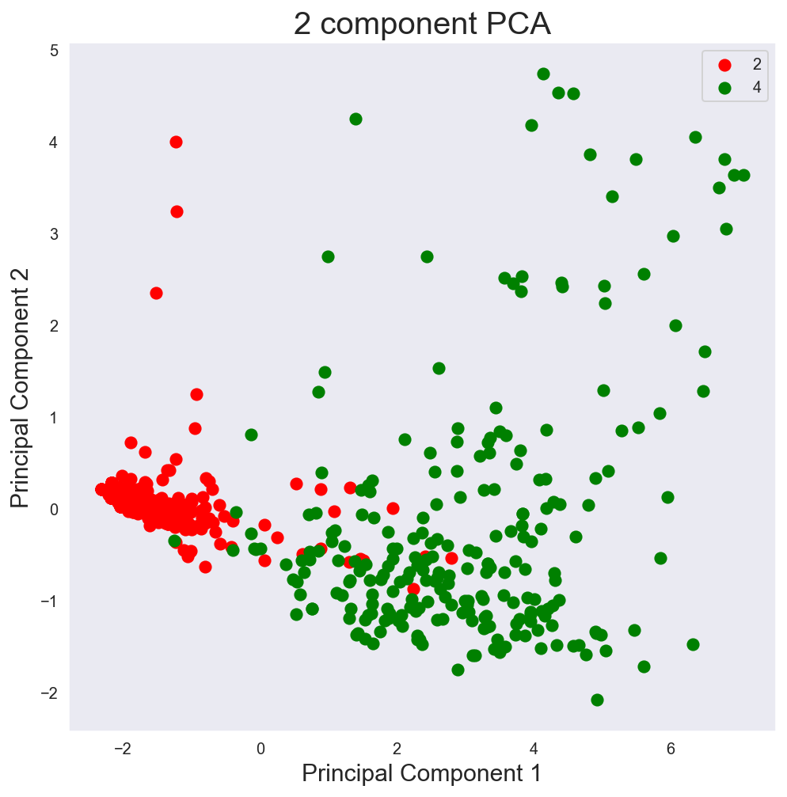

```python
fig = plt.figure(figsize = (8,8))
ax = fig.add_subplot(1,1,1)
ax.set_xlabel('Principal Component 1', fontsize = 15)
ax.set_ylabel('Principal Component 2', fontsize = 15)
ax.set_title('2 component PCA', fontsize = 20)

class_list = data['Class'].tolist()
myset = set(class_list)
targets = list(myset)

colors = ['r', 'g', 'b']
for target, color in zip(targets,colors):
    indicesToKeep = finalDf['Class'] == target
    ax.scatter(finalDf.loc[indicesToKeep, 'principal component 1'], finalDf.loc[indicesToKeep, 'principal component 2'], c = color, s = 50)
ax.legend(targets)
ax.grid()
```

```python
print(pca.explained_variance_)
```

```
[5.8985519  0.77588307]
```

```python
print(pca.explained_variance_ratio_)
```

```
[0.65445704 0.0860859 ]
```

By using the attribute explained_variance*ratio*, you can see that the first principal component contains 65.45% of the variance and the second principal component contains 8.61% of the variance.

## Part 2

#### 1. In Section 1, what kind of relationship can be inferred from summary statistics regarding `ACT composite score` and `SAT total score`? Which visualisations make this relationship apparent?

```python
import pandas as pd

df = pd.read_csv('graduation_rate.csv')

#print('Dataset (head and tail):')
#display(df)

#print('\nParental levels of education:')
#print(df['parental level of education'].unique())

education_order = ['some high school', 'high school', 'some college', "associate's degree", "bachelor's degree", "master's degree"]

df['parental level of education'] = pd.Categorical(df['parental level of education'],
                                                   ordered=True,
                                                   categories=education_order)

print('Univariate summaries:')
display(df.describe())
print("Frequency of parental levels of education:")
freq_education = df['parental level of education'].value_counts()/len(df)
display(freq_education)

print("\nCorrelation coefficients:")
display(df.corr())
```

```
Univariate summaries:
```

|  | ACT composite score | SAT total score | parental income | high school gpa | college gpa | years to graduate |
| --- | --- | --- | --- | --- | --- | --- |
| count | 1000.000000 | 1000.000000 | 1000.000000 | 1000.000000 | 1000.00000 | 1000.000000 |
| mean | 28.557000 | 1997.803000 | 66564.905000 | 3.712900 | 3.36990 | 4.992000 |
| std | 2.776051 | 142.736442 | 19451.865744 | 0.283415 | 0.23622 | 1.403533 |
| min | 19.000000 | 1498.000000 | 1882.000000 | 2.700000 | 2.70000 | 3.000000 |
| 25% | 27.000000 | 1907.750000 | 53443.000000 | 3.500000 | 3.20000 | 4.000000 |
| 50% | 29.000000 | 1999.000000 | 65441.000000 | 3.800000 | 3.40000 | 5.000000 |
| 75% | 30.000000 | 2092.250000 | 79845.250000 | 4.000000 | 3.50000 | 6.000000 |
| max | 36.000000 | 2397.000000 | 120391.000000 | 4.000000 | 4.00000 | 10.000000 |

```
Frequency of parental levels of education:
```

```
some college          0.224
associate's degree    0.213
high school           0.196
some high school      0.196
bachelor's degree     0.103
master's degree       0.068
Name: parental level of education, dtype: float64
```

```
Correlation coefficients:
```

|  | ACT composite score | SAT total score | parental income | high school gpa | college gpa | years to graduate |
| --- | --- | --- | --- | --- | --- | --- |
| ACT composite score | 1.000000 | 0.885884 | 0.183879 | 0.874206 | 0.507349 | -0.129880 |
| SAT total score | 0.885884 | 1.000000 | 0.247556 | 0.910425 | 0.518257 | -0.125523 |
| parental income | 0.183879 | 0.247556 | 1.000000 | 0.227238 | 0.460863 | -0.239500 |
| high school gpa | 0.874206 | 0.910425 | 0.227238 | 1.000000 | 0.492489 | -0.119524 |
| college gpa | 0.507349 | 0.518257 | 0.460863 | 0.492489 | 1.000000 | -0.467499 |
| years to graduate | -0.129880 | -0.125523 | -0.239500 | -0.119524 | -0.467499 | 1.000000 |

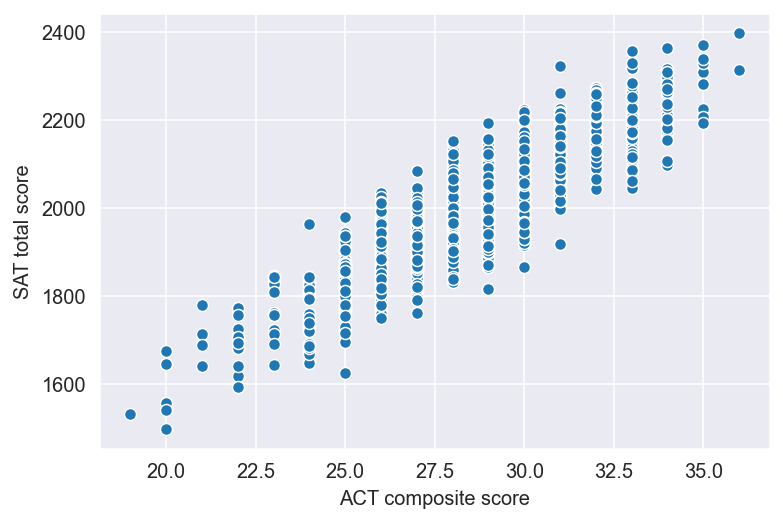

```python
sns.scatterplot(x='ACT composite score', y='SAT total score', data=df)
plt.show()
```

the relatonship between ACT composite score and SAT total score is a positive the scatter plot makes the relationship apparent

#### 2. Based on the box plots presented in Section 1, what is the relationship between parental level of education and parental income? Using table visualisation, find and show the entire rows that correspond to the outliers regarding parental income whose parents have a master's degree.

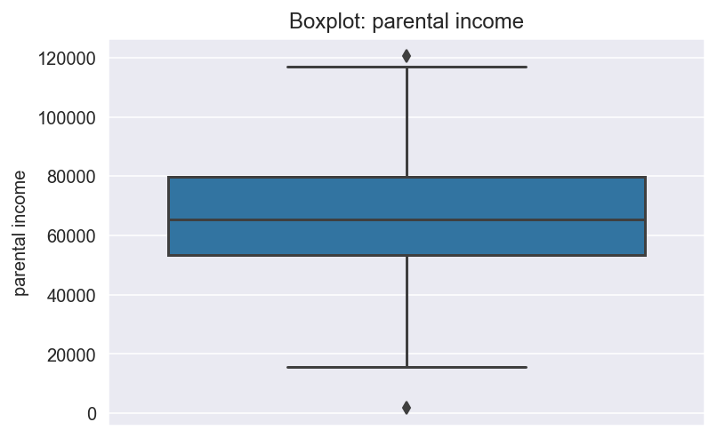

```python
sns.boxplot(df['parental income'], orient='v')
plt.title('Boxplot: parental income')
plt.show()
```

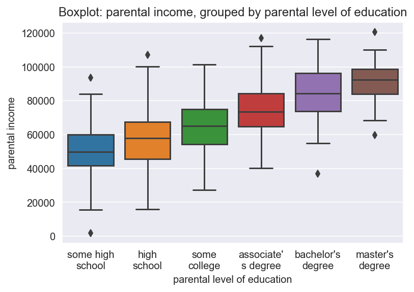

```python
ax = sns.boxplot(x='parental level of education', y='parental income', data=df)
plt.title('Boxplot: parental income, grouped by parental level of education')

# Wrap xticks
import textwrap
ax.set_xticklabels([textwrap.fill(t.get_text(), 10)  for t in ax.get_xticklabels()])

plt.show()
```

```python
df.head()
```

|  | ACT composite score | SAT total score | parental level of education | parental income | high school gpa | college gpa | years to graduate |
| --- | --- | --- | --- | --- | --- | --- | --- |
| 0 | 30 | 2206 | master's degree | 94873 | 4.0 | 3.8 | 3 |
| 1 | 26 | 1953 | some college | 42767 | 3.6 | 2.7 | 9 |
| 2 | 28 | 2115 | some high school | 46316 | 4.0 | 3.3 | 5 |
| 3 | 33 | 2110 | some high school | 52370 | 4.0 | 3.5 | 4 |
| 4 | 30 | 2168 | bachelor's degree | 92665 | 4.0 | 3.6 | 4 |

```python
#display(df[df['parental level of education'] == "master's degree"].sort_values(by='high school gpa', ascending=False))
(df.loc[df['parental level of education'] == "master's degree",["parental income"]])
```

|  | parental income |
| --- | --- |
| 0 | 94873 |
| 27 | 96573 |
| 37 | 90775 |
| 65 | 75974 |
| 99 | 85135 |
| ... | ... |
| 912 | 83814 |
| 927 | 92185 |
| 929 | 79398 |
| 964 | 93314 |
| 968 | 85534 |

68 rows × 1 columns

```python
import numpy as np
from scipy import stats


data = df.loc[df['parental level of education'] == "master's degree","parental income"].tolist()


mean = np.mean(data)
std = np.std(data)
print('mean of the dataset is', mean)
print('std. deviation is', std)

threshold = 2
outlier = []
for i in data:
    z = (i-mean)/std
    if np.abs(z) > threshold:
        outlier.append(i)
print('outlier in dataset is', outlier)
```

```
mean of the dataset is 91718.63235294117
std. deviation is 10965.103920947971
outlier in dataset is [120391, 59724, 68319]
```

```python
df.loc[df['parental income'].isin(outlier)]
```

|  | ACT composite score | SAT total score | parental level of education | parental income | high school gpa | college gpa | years to graduate |
| --- | --- | --- | --- | --- | --- | --- | --- |
| 411 | 31 | 2108 | master's degree | 120391 | 4.0 | 3.6 | 4 |
| 420 | 28 | 2097 | master's degree | 59724 | 3.9 | 3.2 | 4 |
| 641 | 32 | 2274 | master's degree | 68319 | 4.0 | 3.6 | 4 |

#### 3. Using an example, explain the importance of scaling features so that their magnitudes are comparable when computing distances.

Most of the times, a dataset will contain features highly varying in magnitudes, units and range. But since, most of the machine learning algorithms use Eucledian distance between two data points in their computations, this is a problem. If left alone, these algorithms only take in the magnitude of features neglecting the units.

For example, The results would vary greatly between different units, 5kg and 5000gms. The features with high magnitudes will weigh in a lot more in the distance calculations than features with low magnitudes.

To supress this effect, we need to bring all features to the same level of magnitudes. This can be acheived by feature scaling.

#### 4. In Section 1, the distance matrix visualisation is not very informative. However, it is still possible to infer that the average distance between students whose parents only have some high school education and students whose parents have a master's degree is larger than the average distance between students whose parents only have some high school education. Explain how this inference is possible from the visualisation.

```
(1000, 7)
```

```
(1000, 1000)
```

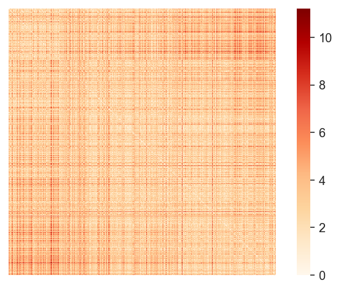

```python
from sklearn.preprocessing import StandardScaler
from scipy.spatial import distance

display(df.shape)

df_sorted = df.sort_values(by='parental level of education', ascending=True)
parental_education_sorted = df_sorted['parental level of education']

#display(parental_education_sorted)

X = df_sorted.drop(columns='parental level of education').to_numpy()



scaler = StandardScaler()
X = scaler.fit_transform(X)

dist = distance.squareform(distance.pdist(X))
sns.heatmap(dist, square=True, xticklabels=False, yticklabels=False, cmap='OrRd')

display(dist.shape)

plt.show()
```

As we can see from the Heatmap the top left corner where the distance between students whose parents only have some high school education lay is light shaded which infer the distances are short.

However, as you move to the lower left corner where the distances between students whose parents only have some high school education and students whose parents have a master's degree lay is darker shaded which infer the distances are larger.

#### 5. In Section 2, increase the number of evenly spaced numbers from 10 to 100 for both axes and observe the corresponding heat map created through nearest neighbour interpolation. Read about this interpolation method and explain what you observed.

|  | x | y | z = f(x,y) |
| --- | --- | --- | --- |
| 0 | -1.000000 | -1.0 | 2.000000 |
| 1 | -0.777778 | -1.0 | 1.604938 |
| 2 | -0.555556 | -1.0 | 1.308642 |
| 3 | -0.333333 | -1.0 | 1.111111 |
| 4 | -0.111111 | -1.0 | 1.012346 |
| ... | ... | ... | ... |
| 95 | 0.111111 | 1.0 | 1.012346 |
| 96 | 0.333333 | 1.0 | 1.111111 |
| 97 | 0.555556 | 1.0 | 1.308642 |
| 98 | 0.777778 | 1.0 | 1.604938 |
| 99 | 1.000000 | 1.0 | 2.000000 |

100 rows × 3 columns

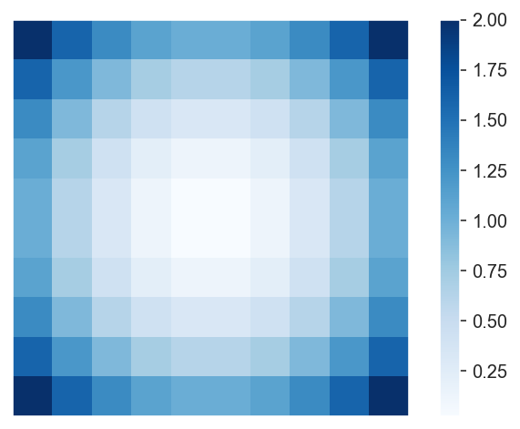

```python
import numpy as np
x_range = np.linspace(-1, 1, 10)
y_range = np.linspace(-1, 1, 10)

# meshgrid: X[i, j] == x_range[j] and Y[i, j] == y_range[i]
X, Y = np.meshgrid(x_range, y_range)

# Z[i, j] == f(x_range[j], y_range[i])
Z = X**2 + Y**2

# Dataset representation
df = pd.DataFrame({'x': X.reshape(-1), 'y': Y.reshape(-1), 'z = f(x,y)': Z.reshape(-1)})
display(df)

# Interpolation: point (x, y) is colored according to the value z of the nearest point in the dataset
plt.imshow(Z, cmap='Blues', aspect='equal', interpolation='nearest')
plt.colorbar()

# xticks and yticks would show Z matrix indices
plt.xticks([])
plt.yticks([])

plt.show()
```

|  | x | y | z = f(x,y) |
| --- | --- | --- | --- |
| 0 | -1.000000 | -1.0 | 2.000000 |
| 1 | -0.979798 | -1.0 | 1.960004 |
| 2 | -0.959596 | -1.0 | 1.920824 |
| 3 | -0.939394 | -1.0 | 1.882461 |
| 4 | -0.919192 | -1.0 | 1.844914 |
| ... | ... | ... | ... |
| 9995 | 0.919192 | 1.0 | 1.844914 |
| 9996 | 0.939394 | 1.0 | 1.882461 |
| 9997 | 0.959596 | 1.0 | 1.920824 |
| 9998 | 0.979798 | 1.0 | 1.960004 |
| 9999 | 1.000000 | 1.0 | 2.000000 |

10000 rows × 3 columns

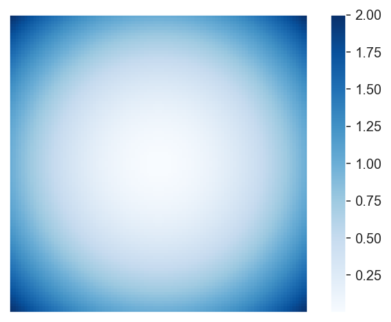

```python
import numpy as np
x_range = np.linspace(-1, 1, 100)
y_range = np.linspace(-1, 1, 100)

# meshgrid: X[i, j] == x_range[j] and Y[i, j] == y_range[i]
X, Y = np.meshgrid(x_range, y_range)

# Z[i, j] == f(x_range[j], y_range[i])
Z = X**2 + Y**2

#display(z.shape)


# Dataset representation
df = pd.DataFrame({'x': X.reshape(-1), 'y': Y.reshape(-1), 'z = f(x,y)': Z.reshape(-1)})
display(df)

# Interpolation: point (x, y) is colored according to the value z of the nearest point in the dataset
plt.imshow(Z, cmap='Blues', aspect='equal', interpolation='nearest')
plt.colorbar()

# xticks and yticks would show Z matrix indices
plt.xticks([])
plt.yticks([])

plt.show()
```

Interpolation is the process of finding a value between two points on a line or a curve. To help us remember what it means, we should think of the first part of the word, 'inter,' as meaning 'enter,' which reminds us to look 'inside' the data we originally had. This tool, interpolation, is not only useful in statistics, but is also useful in science, business, or when there is a need to predict values that fall within two existing data points.

And here we are using the nearest neighbor interpolation algorithm and the principle of this algorithm is to find the nearest point in the original image, and then insert the pixel value of this point into the target image. The advantage of the nearest neighbor interpolation algorithm is that the algorithm is simple and easy achieve.

as we chnaged te 10x10 to the 100x100 the image got smoother

#### 6. The function load_wine from sklearn.datasets can be used to load the wine dataset into a DataFrame by using the commands df = load_wine(), df = pd.DataFrame(data.data, columns=data.feature_names), and df['target'] = pd.Series(data.target).

##### 6.1 Load the wine dataset. Which feature is categorical? Compute the frequency of each value of the categorical feature.

```python
from sklearn.datasets import load_wine
import matplotlib.image as mpimg
import numpy as np
import pandas as pd
from scipy import stats
import re
import matplotlib.pyplot as plt
import math
import pingouin as pg
from sklearn.decomposition import PCA
from sklearn.preprocessing import StandardScaler

wine_data = load_wine()
df = pd.DataFrame(wine_data.data, columns=wine_data.feature_names)
df['target'] = pd.Series(wine_data.target)
```

```python
display( df.describe() )
display( df )
display(wine_data.target_names)
```

|  | alcohol | malic_acid | ash | alcalinity_of_ash | magnesium | total_phenols | flavanoids | nonflavanoid_phenols | proanthocyanins | color_intensity | hue | od280/od315_of_diluted_wines | proline | target |
| --- | --- | --- | --- | --- | --- | --- | --- | --- | --- | --- | --- | --- | --- | --- |
| count | 178.000000 | 178.000000 | 178.000000 | 178.000000 | 178.000000 | 178.000000 | 178.000000 | 178.000000 | 178.000000 | 178.000000 | 178.000000 | 178.000000 | 178.000000 | 178.000000 |
| mean | 13.000618 | 2.336348 | 2.366517 | 19.494944 | 99.741573 | 2.295112 | 2.029270 | 0.361854 | 1.590899 | 5.058090 | 0.957449 | 2.611685 | 746.893258 | 0.938202 |
| std | 0.811827 | 1.117146 | 0.274344 | 3.339564 | 14.282484 | 0.625851 | 0.998859 | 0.124453 | 0.572359 | 2.318286 | 0.228572 | 0.709990 | 314.907474 | 0.775035 |
| min | 11.030000 | 0.740000 | 1.360000 | 10.600000 | 70.000000 | 0.980000 | 0.340000 | 0.130000 | 0.410000 | 1.280000 | 0.480000 | 1.270000 | 278.000000 | 0.000000 |
| 25% | 12.362500 | 1.602500 | 2.210000 | 17.200000 | 88.000000 | 1.742500 | 1.205000 | 0.270000 | 1.250000 | 3.220000 | 0.782500 | 1.937500 | 500.500000 | 0.000000 |
| 50% | 13.050000 | 1.865000 | 2.360000 | 19.500000 | 98.000000 | 2.355000 | 2.135000 | 0.340000 | 1.555000 | 4.690000 | 0.965000 | 2.780000 | 673.500000 | 1.000000 |
| 75% | 13.677500 | 3.082500 | 2.557500 | 21.500000 | 107.000000 | 2.800000 | 2.875000 | 0.437500 | 1.950000 | 6.200000 | 1.120000 | 3.170000 | 985.000000 | 2.000000 |
| max | 14.830000 | 5.800000 | 3.230000 | 30.000000 | 162.000000 | 3.880000 | 5.080000 | 0.660000 | 3.580000 | 13.000000 | 1.710000 | 4.000000 | 1680.000000 | 2.000000 |

|  | alcohol | malic_acid | ash | alcalinity_of_ash | magnesium | total_phenols | flavanoids | nonflavanoid_phenols | proanthocyanins | color_intensity | hue | od280/od315_of_diluted_wines | proline | target |
| --- | --- | --- | --- | --- | --- | --- | --- | --- | --- | --- | --- | --- | --- | --- |
| 0 | 14.23 | 1.71 | 2.43 | 15.6 | 127.0 | 2.80 | 3.06 | 0.28 | 2.29 | 5.64 | 1.04 | 3.92 | 1065.0 | 0 |
| 1 | 13.20 | 1.78 | 2.14 | 11.2 | 100.0 | 2.65 | 2.76 | 0.26 | 1.28 | 4.38 | 1.05 | 3.40 | 1050.0 | 0 |
| 2 | 13.16 | 2.36 | 2.67 | 18.6 | 101.0 | 2.80 | 3.24 | 0.30 | 2.81 | 5.68 | 1.03 | 3.17 | 1185.0 | 0 |
| 3 | 14.37 | 1.95 | 2.50 | 16.8 | 113.0 | 3.85 | 3.49 | 0.24 | 2.18 | 7.80 | 0.86 | 3.45 | 1480.0 | 0 |
| 4 | 13.24 | 2.59 | 2.87 | 21.0 | 118.0 | 2.80 | 2.69 | 0.39 | 1.82 | 4.32 | 1.04 | 2.93 | 735.0 | 0 |
| ... | ... | ... | ... | ... | ... | ... | ... | ... | ... | ... | ... | ... | ... | ... |
| 173 | 13.71 | 5.65 | 2.45 | 20.5 | 95.0 | 1.68 | 0.61 | 0.52 | 1.06 | 7.70 | 0.64 | 1.74 | 740.0 | 2 |
| 174 | 13.40 | 3.91 | 2.48 | 23.0 | 102.0 | 1.80 | 0.75 | 0.43 | 1.41 | 7.30 | 0.70 | 1.56 | 750.0 | 2 |
| 175 | 13.27 | 4.28 | 2.26 | 20.0 | 120.0 | 1.59 | 0.69 | 0.43 | 1.35 | 10.20 | 0.59 | 1.56 | 835.0 | 2 |
| 176 | 13.17 | 2.59 | 2.37 | 20.0 | 120.0 | 1.65 | 0.68 | 0.53 | 1.46 | 9.30 | 0.60 | 1.62 | 840.0 | 2 |
| 177 | 14.13 | 4.10 | 2.74 | 24.5 | 96.0 | 2.05 | 0.76 | 0.56 | 1.35 | 9.20 | 0.61 | 1.60 | 560.0 | 2 |

178 rows × 14 columns

```
array(['class_0', 'class_1', 'class_2'], dtype='<U7')
```

```python
train_data = np.array(wine_data.data)
train_labels = np.array(wine_data.target)

num_features = wine_data.data.shape[1]
unique_labels = np.unique(train_labels)
num_classes = len(unique_labels)

#display(train_labels)
display(unique_labels)
display(num_classes)
```

[output not shown]

```python
print("The wine dataset has " + str(num_features) + " features")
print(wine_data.feature_names)
print("The wine dataset has " + str(num_classes) + " categoryes")
print(wine_data.target_names)
```

```
The wine dataset has 13 features
['alcohol', 'malic_acid', 'ash', 'alcalinity_of_ash', 'magnesium', 'total_phenols', 'flavanoids', 'nonflavanoid_phenols', 'proanthocyanins', 'color_intensity', 'hue', 'od280/od315_of_diluted_wines', 'proline']
The wine dataset has 3 categoryes
['class_0' 'class_1' 'class_2']
```

```python
print("Frequency of the categorical feature:")
freq_categorical_feature = df['target'].value_counts()/len(df)
display(freq_categorical_feature)
```

```
Frequency of the categorical feature:
```

```
1    0.398876
0    0.331461
2    0.269663
Name: target, dtype: float64
```

##### 6.2 Compute univariate and multivariate summaries for all the numerical features. Group observations by the categorical feature and compute the corresponding median for each remaining numerical feature

```python
print('Univariate summaries:')
display(df.describe())

print("\nCorrelation coefficients:")
display(df.corr())

print('Group observations by the categorical feature and compute the corresponding median for each remaining numerical feature:')
display(df.groupby('target').median())
```

```
Univariate summaries:
```

|  | alcohol | malic_acid | ash | alcalinity_of_ash | magnesium | total_phenols | flavanoids | nonflavanoid_phenols | proanthocyanins | color_intensity | hue | od280/od315_of_diluted_wines | proline | target |
| --- | --- | --- | --- | --- | --- | --- | --- | --- | --- | --- | --- | --- | --- | --- |
| count | 178.000000 | 178.000000 | 178.000000 | 178.000000 | 178.000000 | 178.000000 | 178.000000 | 178.000000 | 178.000000 | 178.000000 | 178.000000 | 178.000000 | 178.000000 | 178.000000 |
| mean | 13.000618 | 2.336348 | 2.366517 | 19.494944 | 99.741573 | 2.295112 | 2.029270 | 0.361854 | 1.590899 | 5.058090 | 0.957449 | 2.611685 | 746.893258 | 0.938202 |
| std | 0.811827 | 1.117146 | 0.274344 | 3.339564 | 14.282484 | 0.625851 | 0.998859 | 0.124453 | 0.572359 | 2.318286 | 0.228572 | 0.709990 | 314.907474 | 0.775035 |
| min | 11.030000 | 0.740000 | 1.360000 | 10.600000 | 70.000000 | 0.980000 | 0.340000 | 0.130000 | 0.410000 | 1.280000 | 0.480000 | 1.270000 | 278.000000 | 0.000000 |
| 25% | 12.362500 | 1.602500 | 2.210000 | 17.200000 | 88.000000 | 1.742500 | 1.205000 | 0.270000 | 1.250000 | 3.220000 | 0.782500 | 1.937500 | 500.500000 | 0.000000 |
| 50% | 13.050000 | 1.865000 | 2.360000 | 19.500000 | 98.000000 | 2.355000 | 2.135000 | 0.340000 | 1.555000 | 4.690000 | 0.965000 | 2.780000 | 673.500000 | 1.000000 |
| 75% | 13.677500 | 3.082500 | 2.557500 | 21.500000 | 107.000000 | 2.800000 | 2.875000 | 0.437500 | 1.950000 | 6.200000 | 1.120000 | 3.170000 | 985.000000 | 2.000000 |
| max | 14.830000 | 5.800000 | 3.230000 | 30.000000 | 162.000000 | 3.880000 | 5.080000 | 0.660000 | 3.580000 | 13.000000 | 1.710000 | 4.000000 | 1680.000000 | 2.000000 |

```
Correlation coefficients:
```

|  | alcohol | malic_acid | ash | alcalinity_of_ash | magnesium | total_phenols | flavanoids | nonflavanoid_phenols | proanthocyanins | color_intensity | hue | od280/od315_of_diluted_wines | proline | target |
| --- | --- | --- | --- | --- | --- | --- | --- | --- | --- | --- | --- | --- | --- | --- |
| alcohol | 1.000000 | 0.094397 | 0.211545 | -0.310235 | 0.270798 | 0.289101 | 0.236815 | -0.155929 | 0.136698 | 0.546364 | -0.071747 | 0.072343 | 0.643720 | -0.328222 |
| malic_acid | 0.094397 | 1.000000 | 0.164045 | 0.288500 | -0.054575 | -0.335167 | -0.411007 | 0.292977 | -0.220746 | 0.248985 | -0.561296 | -0.368710 | -0.192011 | 0.437776 |
| ash | 0.211545 | 0.164045 | 1.000000 | 0.443367 | 0.286587 | 0.128980 | 0.115077 | 0.186230 | 0.009652 | 0.258887 | -0.074667 | 0.003911 | 0.223626 | -0.049643 |
| alcalinity_of_ash | -0.310235 | 0.288500 | 0.443367 | 1.000000 | -0.083333 | -0.321113 | -0.351370 | 0.361922 | -0.197327 | 0.018732 | -0.273955 | -0.276769 | -0.440597 | 0.517859 |
| magnesium | 0.270798 | -0.054575 | 0.286587 | -0.083333 | 1.000000 | 0.214401 | 0.195784 | -0.256294 | 0.236441 | 0.199950 | 0.055398 | 0.066004 | 0.393351 | -0.209179 |
| total_phenols | 0.289101 | -0.335167 | 0.128980 | -0.321113 | 0.214401 | 1.000000 | 0.864564 | -0.449935 | 0.612413 | -0.055136 | 0.433681 | 0.699949 | 0.498115 | -0.719163 |
| flavanoids | 0.236815 | -0.411007 | 0.115077 | -0.351370 | 0.195784 | 0.864564 | 1.000000 | -0.537900 | 0.652692 | -0.172379 | 0.543479 | 0.787194 | 0.494193 | -0.847498 |
| nonflavanoid_phenols | -0.155929 | 0.292977 | 0.186230 | 0.361922 | -0.256294 | -0.449935 | -0.537900 | 1.000000 | -0.365845 | 0.139057 | -0.262640 | -0.503270 | -0.311385 | 0.489109 |
| proanthocyanins | 0.136698 | -0.220746 | 0.009652 | -0.197327 | 0.236441 | 0.612413 | 0.652692 | -0.365845 | 1.000000 | -0.025250 | 0.295544 | 0.519067 | 0.330417 | -0.499130 |
| color_intensity | 0.546364 | 0.248985 | 0.258887 | 0.018732 | 0.199950 | -0.055136 | -0.172379 | 0.139057 | -0.025250 | 1.000000 | -0.521813 | -0.428815 | 0.316100 | 0.265668 |
| hue | -0.071747 | -0.561296 | -0.074667 | -0.273955 | 0.055398 | 0.433681 | 0.543479 | -0.262640 | 0.295544 | -0.521813 | 1.000000 | 0.565468 | 0.236183 | -0.617369 |
| od280/od315_of_diluted_wines | 0.072343 | -0.368710 | 0.003911 | -0.276769 | 0.066004 | 0.699949 | 0.787194 | -0.503270 | 0.519067 | -0.428815 | 0.565468 | 1.000000 | 0.312761 | -0.788230 |
| proline | 0.643720 | -0.192011 | 0.223626 | -0.440597 | 0.393351 | 0.498115 | 0.494193 | -0.311385 | 0.330417 | 0.316100 | 0.236183 | 0.312761 | 1.000000 | -0.633717 |
| target | -0.328222 | 0.437776 | -0.049643 | 0.517859 | -0.209179 | -0.719163 | -0.847498 | 0.489109 | -0.499130 | 0.265668 | -0.617369 | -0.788230 | -0.633717 | 1.000000 |

```
Group observations by the categorical feature and compute the corresponding median for each remaining numerical feature:
```

| target | alcohol | malic_acid | ash | alcalinity_of_ash | magnesium | total_phenols | flavanoids | nonflavanoid_phenols | proanthocyanins | color_intensity | hue | od280/od315_of_diluted_wines | proline |
| --- | --- | --- | --- | --- | --- | --- | --- | --- | --- | --- | --- | --- | --- |
| 0 | 13.750 | 1.770 | 2.44 | 16.8 | 104.0 | 2.800 | 2.980 | 0.29 | 1.870 | 5.40 | 1.070 | 3.17 | 1095.0 |
| 1 | 12.290 | 1.610 | 2.24 | 20.0 | 88.0 | 2.200 | 2.030 | 0.37 | 1.610 | 2.90 | 1.040 | 2.83 | 495.0 |
| 2 | 13.165 | 3.265 | 2.38 | 21.0 | 97.0 | 1.635 | 0.685 | 0.47 | 1.105 | 7.55 | 0.665 | 1.66 | 627.5 |

##### 6.3 Group observations by the categorical feature and create one box plot of alcohol for each group.

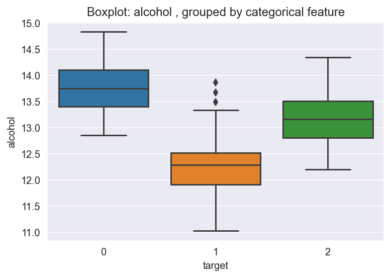

```python
ax = sns.boxplot(x='target', y='alcohol', data=df)
plt.title('Boxplot: alcohol , grouped by categorical feature')

# Wrap xticks
import textwrap
ax.set_xticklabels([textwrap.fill(t.get_text(), 10)  for t in ax.get_xticklabels()])

plt.show()
```

##### 6.4 Create a scatter plot for the pair of **distinct** numerical features with the highest correlation.

```python
def get_feature_correlation(df, top_n=None, corr_method='spearman',
                            remove_duplicates=True, remove_self_correlations=True):
    """
    Compute the feature correlation and sort feature pairs based on their correlation

    :param df: The dataframe with the predictor variables
    :type df: pandas.core.frame.DataFrame
    :param top_n: Top N feature pairs to be reported (if None, all of the pairs will be returned)
    :param corr_method: Correlation compuation method
    :type corr_method: str
    :param remove_duplicates: Indicates whether duplicate features must be removed
    :type remove_duplicates: bool
    :param remove_self_correlations: Indicates whether self correlations will be removed
    :type remove_self_correlations: bool

    :return: pandas.core.frame.DataFrame
    """
    corr_matrix_abs = df.corr(method=corr_method).abs()
    corr_matrix_abs_us = corr_matrix_abs.unstack()
    sorted_correlated_features = corr_matrix_abs_us \
        .sort_values(kind="quicksort", ascending=False) \
        .reset_index()

    # Remove comparisons of the same feature
    if remove_self_correlations:
        sorted_correlated_features = sorted_correlated_features[
            (sorted_correlated_features.level_0 != sorted_correlated_features.level_1)
        ]

    # Remove duplicates
    if remove_duplicates:
        sorted_correlated_features = sorted_correlated_features.iloc[:-2:2]

    # Create meaningful names for the columns
    sorted_correlated_features.columns = ['Feature 1', 'Feature 2', 'Correlation (abs)']

    if top_n:
        return sorted_correlated_features[:top_n]

    return sorted_correlated_features


print(get_feature_correlation(df,2))
```

```
     Feature 1      Feature 2  Correlation (abs)
14  flavanoids  total_phenols           0.879404
16      target     flavanoids           0.854908
```

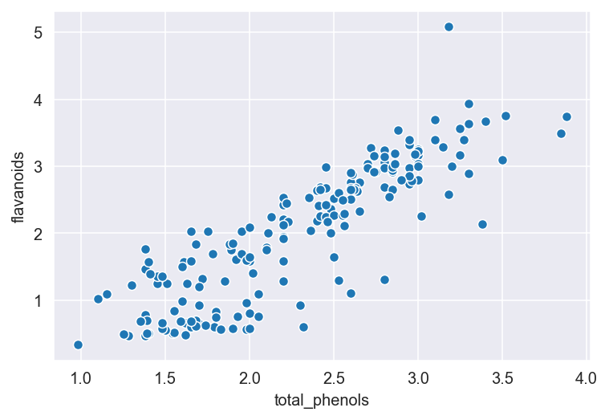

```python
sns.scatterplot(x='total_phenols', y='flavanoids', data=df)
plt.show()
```

##### 6.5 Exclude the categorical feature, standardize the numerical features, and display a projection obtained by multidimensional scaling. Color the points by the categorical feature.

```python
features = list(df.columns)
features.remove('target')
features

# Separating out the features
x = df.loc[:, features].values
# Separating out the target
y = df.loc[:,['target']].values
# Standardizing the features
x = StandardScaler().fit_transform(x)
```

```python
pca = PCA(n_components=2)
principalComponents = pca.fit_transform(x)
principalDf = pd.DataFrame(data = principalComponents , columns = ['principal component 1', 'principal component 2'])
```

```python
finalDf = pd.concat([principalDf, df[['target']]], axis = 1)
finalDf
```

|  | principal component 1 | principal component 2 | target |
| --- | --- | --- | --- |
| 0 | 3.316751 | -1.443463 | 0 |
| 1 | 2.209465 | 0.333393 | 0 |
| 2 | 2.516740 | -1.031151 | 0 |
| 3 | 3.757066 | -2.756372 | 0 |
| 4 | 1.008908 | -0.869831 | 0 |
| ... | ... | ... | ... |
| 173 | -3.370524 | -2.216289 | 2 |
| 174 | -2.601956 | -1.757229 | 2 |
| 175 | -2.677839 | -2.760899 | 2 |
| 176 | -2.387017 | -2.297347 | 2 |
| 177 | -3.208758 | -2.768920 | 2 |

178 rows × 3 columns

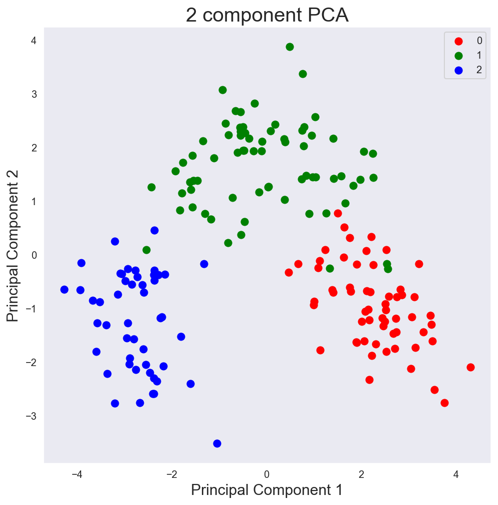

```python
fig = plt.figure(figsize = (8,8))
ax = fig.add_subplot(1,1,1)
ax.set_xlabel('Principal Component 1', fontsize = 15)
ax.set_ylabel('Principal Component 2', fontsize = 15)
ax.set_title('2 component PCA', fontsize = 20)

class_list = df['target'].tolist()
myset = set(class_list)
targets = list(myset)

colors = ['r', 'g', 'b']
for target, color in zip(targets,colors):
    indicesToKeep = finalDf['target'] == target
    ax.scatter(finalDf.loc[indicesToKeep, 'principal component 1'], finalDf.loc[indicesToKeep, 'principal component 2'], c = color, s = 50)
ax.legend(targets)
ax.grid()
```